# Arsenic Project Reconstruction in R

Robert Sellers / Callan O’Conner

The Jackson Laboratory

29 December 2020

# 1 Project summary

A *systems toxicology* proof of principle

Grant proposal: ./NIEHS_ArsenicProposal_Science.pdf

Hypothesis: *Genetic analysis in the context of a quantitative environmental perturbation will reveal multiple, novel, and diverse biochemical networks that respond to chemical exposure.*

Study design evaluation / statistical methods development (**Aim 1**) - Sample size determination, GxE (qtl?) mapping, hypothesis formulation - Dose-response and benchmark dose development / analysis - Omics data pathways analysis (TBD) - Subsequent animal / cell-line validation (TBD)

In Vitro Analysis (**Aim 2**) - Arsenic exposure in primary cell cultures - Accumulate physiologically informative cellular features / phenotypes in 3 main categories: - cytotoxicity - genotoxicity - oxidative stress - Identify genetic factors of susceptibility and resistance (i.e. whole organism response and/or discovered molecular pathways)

In Vivo Renal (**Aim 3**) - TBD

# 2 R package environment

```r
library(data.tree) # project mapping chunk
library(DiagrammeR) # project mapping chunk
library(readr)
library(dplyr, warn.conflicts = FALSE)
library(plyr) # for rbind.fill function
library(stringr)
library(drc) # dose response library
library(ggpubr)
library(janitor) # for clean_names() bulk column renaming
library(rstan)
library(multidplyr) # multi-core dplyr
library(factoextra) # PCA Analysis
library(corrplot) # PCA Analysis
```

# 3 Project metadata

*uses inline markdown*

```r
#do_cohort_sample_size <- 640
exposure_to_labeling_duration_hours <- 24
founders_replicates <- data.frame()
concentration_arr <- c(0, 0.1, 0.5, 1, 2, 3, 4, 5) # in ppm
do_screen_sample_size <- 250
arsenic_exposure_limit <- 0.01 # in ppm
do_founders <- c("AJ", "B6", "129", "NOD", "NZO", "CAST", "PWK", "WSB")
#image_scale <- 200000

# collaborative cross / inbred
# diversity outcross / outbred
# collaborative cross RIX F1 CC-RIX F1

# hoescht features
# nuclei count, nuclear area, nuclear roundness, nuclear symmetry, nuclear length, hoescht intensity
# mitotracker
# cell area, cell roundness, cell length, cell symmetry, cell compactness, radial profile, mitotracker-homogeneity, mitotracker intensity, mitotracker intensity
#mitochondrial texture - bright,dark,valley,saddle,edge,spot,hole
# H2AX
# num spots, postive/negative, texture: bright,dark,valley,saddle,edge,spot,hole

#micronucleated vs multinucleated cells
```

# 4 Data loading & tidying

## 4.1 Scripts

So far contains…

- code that generates plate class objects containing
  - given “normal” harmony software output…
  - plate index metadata
  - cell data.frame
  - plate data.frame
  - various input/header metadata variables
- built-in exploration methods / functions (tbd)

```r
add_item_naive <- function(list_name, plate_obj_name, item){
  len_list <- length(.GlobalEnv[[list_name]]) + 1
  .GlobalEnv[[list_name]][[plate_obj_name]] <- item
}

# ensure all NA values are the same
is.nan.data.frame <- function(x){
  do.call(cbind, lapply(x, is.nan))
}

# reads a file containing harmony data evaluations
harmony_read_plate <- function(list_name, dir, e, t = "unknown", run_qa = TRUE){

  plate_obj_name <- paste0(dir,"_e",as.character(e))#paste0(plate_id,"_", batch_id,"_e", e, special_qualifier)

  # create a plate class to keep things organized
  setClass(Class="plate",
   representation(
      evaluation = "numeric",
      index="list",
      plate_df="data.frame",
      cells_df="data.frame",
      cells_header="character",
      plate_header="character",
      #database = "character",
      plate_dir = "character",
      qa = "character"
    ))

  # str determines where files should be if applicable
  index_file <- file.path(dir,"indexfile.txt")
  plate_file <- file.path(dir,paste0("Evaluation",e),"PlateResults.txt")
  cells_file <- file.path(dir,paste0("Evaluation",e),"Objects_Population - Nuclei Selected.txt")

  ###### PLATE FILE#######

  if(file.exists(plate_file)){

    plate_header <- readLines(plate_file,n = 8)

    plate_df <- read_tsv(plate_file,skip=8) %>%
      select_if(function(x) any(!is.na(x))) %>% # removes columns with all NA
      clean_names() # removes spaces and bad characters for underscores

    plate_df[is.nan(plate_df)] <- NA #change NaN to NA

  }
  ###### INDEX FILE#######
  if(file.exists(index_file)){

    idx_df <- read_tsv(index_file) %>%
      select_if(function(x) any(!is.na(x))) %>% # removes columns with all NA
      clean_names() %>%# removes spaces and bad characters for underscores
      mutate(channel_name = gsub("[[:punct:][:blank:]]", "_", channel_name),
             channel_name = tolower(channel_name))

    # split dataframes based on stain value
    idx_df_split <- split(idx_df, idx_df$channel_name)
  }
  ###### CELLS FILE#######
  if(file.exists(cells_file)){

    # read file header
    cells_header <- readLines(cells_file, n = 9)
    #header_split <- str_split(gsub("\t", "__", cells_header, fixed=TRUE), "__")
    #database_name <- header_split[[1]][2] # more here - also get cell file
    # read file data
    cell_df <- read_tsv(cells_file,skip=9) %>%
      select_if(function(x) any(!is.na(x))) %>% # removes columns with all NA
      clean_names() # removes spaces and bad characters for underscores
  }else{
    cells_header <- ''
    cell_df <- data.frame()
  }
  # basic data bottleneck qa
  if(run_qa){

      # validate plate column
      if(!("plate" %in% names(plate_df))){
        qa <- 'fail'
      }else if (!(length(unique(plate_df$plate))==1)){
        qa <- 'fail'
      }else{
        qa <- 'pass'
      }
      # check for missing columns
      #print (paste0("number of columns ", length(colnames(plate_df))))
  }

  # generate new class and append to specified list by plate_obj_name
  new_plate_class <- new("plate",
              evaluation = e,
              index=idx_df_split,
              plate_df=plate_df,
              cells_df=cell_df,
              cells_header=cells_header,
              plate_header=plate_header,
              plate_dir = dir,
              qa = qa
          )

  add_item_naive(list_name, plate_obj_name, new_plate_class)
}
```

## 4.3 Data clean-up

- TBD: explanations
- Data naming conventions need work

```r
# yuck
founder_quantal_plate_list$`founders_data/founders_quantal/Founders_B1_Whole__2020-01-03T10_34_56-Measurement 1_e3`@plate_df <- founder_quantal_plate_list$`founders_data/founders_quantal/Founders_B1_Whole__2020-01-03T10_34_56-Measurement 1_e3`@plate_df %>%
  filter(mouse != "PWK_2F")
founder_quantal_plate_list$`founders_data/founders_quantal/Founders_A1_Whole_New__2020-01-15T13_25_19-Measurement 1_e1`@plate_df <-
founder_quantal_plate_list$`founders_data/founders_quantal/Founders_A1_Whole_New__2020-01-15T13_25_19-Measurement 1_e1`@plate_df %>%
  filter(!is.na(cell_type))
```

## 4.4 Objects as comprehensive sample dataframes

### 4.4.1 In vitro Founders master dataset

- Loads from ./data/discovery_phase/in_vitro/founders_data/founders_quantal

```r
#cluster <- multidplyr::new_cluster(10)

founders_quantal_all_plates_df <- do.call(rbind.fill, lapply(founder_quantal_plate_list, function(x) {x@plate_df})) %>%
  mutate(concentration = factor(concentration)) %>%
  mutate(cell_type = factor(cell_type)) %>%
  dplyr::rename(strain = cell_type) %>%
  #dplyr::rename(batch = individual) %>%
  mutate(strain = factor(strain, levels = c("AJ", "B6", "129", "NOD", "NZO", "CAST", "PWK", "WSB")),
         individual = factor(individual))
```

### 4.4.2 In vitro Diversity Outbred (DO) master dataset

- Loads from ./data/discovery_phase/in_vitro/do_screen/nuclei_counts

```r
#cluster <- multidplyr::new_cluster(10)

conditionally_remove_from_list <- sapply(do_plate_list, function(x) class(x)=="plate" && x@qa == 'pass')

do_all_plates_df <- do.call(rbind.fill, lapply(do_plate_list[conditionally_remove_from_list], function(x) {x@plate_df})) %>%
  mutate(concentration = factor(concentration))

do_all_cells_df <- do.call(rbind.fill, lapply(do_plate_list, function(x) {x@cells_df})) %>%
  mutate(concentration = factor(concentration))
```

# 5 Data Analysis

- the following are found and incorporated analyses

## 5.1 Data Reduction and Variance Analysis

- Analysis of ‘sources of external variation that can influence image analysis and quantification’
- ‘We observed batch effects and additional sources of variation’
  - in sex, litter, freeze/thaw success, replicate number within a well, and differences in cellular labeling.
  - The data was adjusted to correct for these factors prior to dose-response modeling
  - check slide 29 (well-to-well, plate-to-plate, day-to-day)

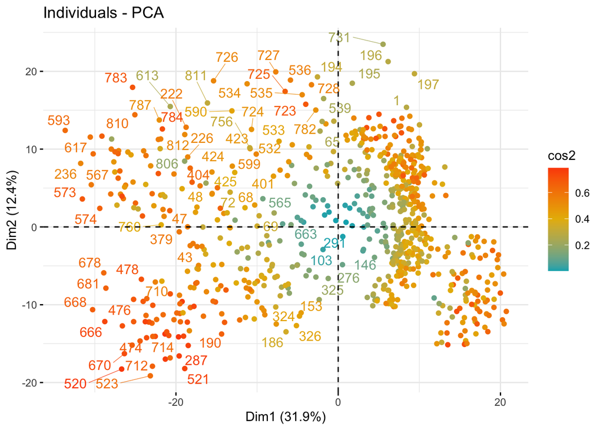

```r
#https://rpubs.com/JanpuHou/278584

test_founders_quantal_corr <- founders_quantal_all_plates_df[, !names(founders_quantal_all_plates_df) %in% c('row','column','number_of_analyzed_fields','concentration','strain','individual','mouse','sex','plane','timepoint')]
test_omit <- na.omit(test_founders_quantal_corr)%>% select_if(colSums(.) != 0)
#cor(tidyr::drop_na(test_founders_quantal_corr))

# Results for Variables
pca_prcomp <- prcomp(test_omit, scale = TRUE) # note the use of na.omit. If you're data still have missing values at this point (which it shouldn't), this should eliminate them.
# Biplot Graphic for individual units (potentially messy)
fviz_pca_ind(pca_prcomp,
             col.ind = "cos2", # Color by the quality of representation
             gradient.cols = c("#00AFBB", "#E7B800", "#FC4E07"),
             repel = TRUE     # Avoid text overlapping
             )
```

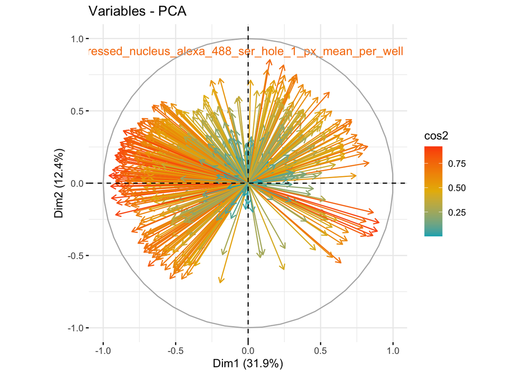

```r
fviz_pca_var(pca_prcomp, col.var = "cos2",
             gradient.cols = c("#00AFBB", "#E7B800", "#FC4E07"),
             repel = TRUE # Avoid text overlapping
             )
```

```r
res.var <- get_pca_var(pca_prcomp)
eig.val <- get_eigenvalue(pca_prcomp)
```

## 5.2 Dose-response & benchmark dose estimation

- Multi-parameter dose response curve fitting summaries
  - Slope
  - EC50
- Used founder strain data to estimate heritability of dose-response parameters
- Heritability estimates for cellular dose response phenotypes were used to establish assay reliability prior to screening DO mice
  - rendering hard-coded images
  - TBD load these dynamically / reproducibly

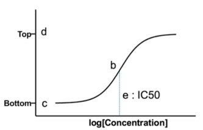

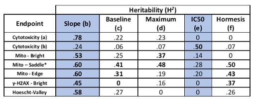

$$c+(d-c)exp(-exp(b(log(x)-log(e))))$$

/founders_scripts/Founders H2AX and Mito summaries.R

-H2AX and Mito summaries -uses quantal dataset

```r
# founders code reproduction

model_H2AX_W2_4 <- drm(h2ax_pos_in_focus ~ as.numeric(concentration),
                       curveid = mouse,
                       data=na.omit(founders_quantal_all_plates_df),
                       fct=W2.4(),
                       pmodels = c(~mouse-1, ~mouse-1, ~mouse-1, ~mouse-1)
                       )

model_H2AX_LL_4 <- drm(h2ax_pos_in_focus ~ as.numeric(concentration),
                       curveid = mouse,
                       data=na.omit(founders_quantal_all_plates_df),
                       fct=LL.4(),
                       pmodels = c(~mouse-1, ~mouse-1, ~mouse-1, ~mouse-1)
                       )

model_stress_W2_4 <- drm(mito_stress_in_focus ~ as.numeric(concentration),
                       curveid = mouse,
                       data=na.omit(founders_quantal_all_plates_df),
                       fct=W2.4(),
                       pmodels = c(~mouse-1, ~mouse-1, ~mouse-1, ~mouse-1)
                       )

model_stress_LL_4 <- drm(mito_stress_in_focus ~ as.numeric(concentration),
                       curveid = mouse,
                       data=na.omit(founders_quantal_all_plates_df),
                       fct=LL.4(),
                       pmodels = c(~mouse-1, ~mouse-1, ~mouse-1, ~mouse-1)
                       )
```

- Example founders’ aggregate DR between concentration and in_focus_number_of_objects
- https://rpubs.com/russH/378543

```r
## Fitting a four-parameter log-logistic model
## with user-defined parameter names
#names_group <- c('plate_id' ,'technician')
log_nuclei_number_of_objects_LL4 <- drm(
  formula = nuclei_number_of_objects ~ as.numeric(concentration),
  curveid = plate, #given plate id
  data = do_all_plates_df,
  fct = LL.4(names = c("Slope", "Lower Limit", "Upper Limit", "ED50"))
  #pmodels=data.fram(1,1,1,1)
  )
```

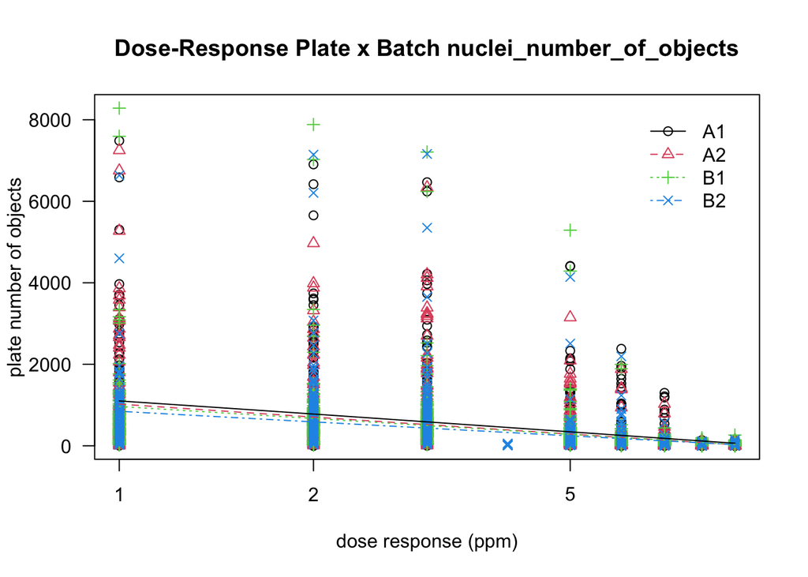

```r
plot(log_nuclei_number_of_objects_LL4,
     xlab="dose response (ppm)",
     ylab="plate number of objects",
     col = TRUE,
     type = 'all',
     #normal = TRUE,
     #ylab = 'feature value',
     #xttrim = FALSE,
    confidence.level = 0.95,
    main="Dose-Response Plate x Batch nuclei_number_of_objects")
```

```r
## Add points
#plot(nuclei_number_of_objects.LL4 ,col = TRUE, add=TRUE)
#provide the four-parameter log-logistic function
summary(log_nuclei_number_of_objects_LL4)
```

```
##
## Model fitted: Log-logistic (ED50 as parameter) (4 parms)
##
## Parameter estimates:
##
##                   Estimate  Std. Error t-value   p-value
## Slope:A1        3.0936e-01          NA      NA        NA
## Slope:A2        1.5753e-01          NA      NA        NA
## Slope:B1        1.9242e-01          NA      NA        NA
## Slope:B2        1.6329e-01  3.3609e-02  4.8586 1.219e-06 ***
## Lower Limit:A1 -2.7073e+03          NA      NA        NA
## Lower Limit:A2 -4.6415e+03          NA      NA        NA
## Lower Limit:B1 -3.7693e+03          NA      NA        NA
## Lower Limit:B2 -3.7418e+03  2.0274e+03 -1.8456   0.06501 .
## Upper Limit:A1  3.4829e+03          NA      NA        NA
## Upper Limit:A2  7.0548e+03          NA      NA        NA
## Upper Limit:B1  5.0881e+03          NA      NA        NA
## Upper Limit:B2  5.4866e+03          NA      NA        NA
## ED50:A1         4.5481e+00  1.9515e+00  2.3306   0.01982 *
## ED50:A2         6.7016e-01          NA      NA        NA
## ED50:B1         2.0506e+00          NA      NA        NA
## ED50:B2         9.3470e-01          NA      NA        NA
## ---
## Signif. codes:  0 '***' 0.001 '**' 0.01 '*' 0.05 '.' 0.1 ' ' 1
##
## Residual standard error:
##
##  636.9926 (4936 degrees of freedom)
```

```r
#confint(log_nuclei_number_of_objects_LL4, level = 0.95)
```

### 5.2.1 DRC boxplot

- tbd handle 0.5 concentration

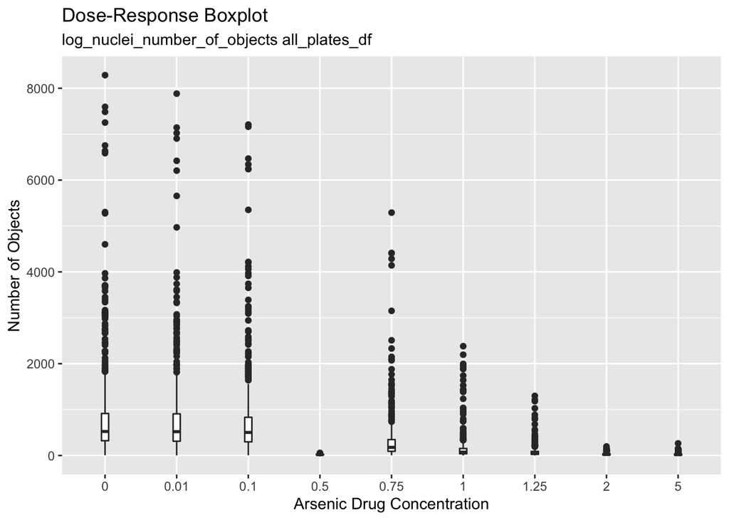

```r
p <- ggplot(
    data = do_all_plates_df, aes(x = concentration, y = nuclei_number_of_objects)
  ) +
  #geom_violin() +
  labs(
    x = "Arsenic Drug Concentration",
    y = "Number of Objects",
    title = 'Dose-Response Boxplot',
    subtitle = 'log_nuclei_number_of_objects all_plates_df'
    ) +
  ylim(0, NA) +
  #stat_summary(fun.y=mean, geom="point", shape=23, size=2) +
  #stat_summary(fun.y=median, geom="point", size=2, color="red")
  geom_boxplot(width=0.1)

p
```

## 5.3 Cell-line feature selection

## 5.4 RIX Validation

- are F1 hybrid mice from pairs of CC strains
- recombinant, inbred intercross, RIX mice
- validation strains for AOPs discovered in DO mice
- TBD

## 5.5 Pathway modeling

- using omics data
- identify predictive biomarkers and ‘key molecular events’
- TBD

# 6 GxE mapping strategy

- map and identify genetic loci that are responsible for individual variation in susceptibility in DO mice using a novel G x E mapping strategy

```r
cluster <- multidplyr::new_cluster(10)
H2AX_par_dat <- founders_quantal_all_plates_df %>%
  ## Important covariates
  dplyr::select(strain, sex, mouse, individual) %>%
  ## Weibull parameters
  left_join(data.frame(mouse = names(coef(model_H2AX_W2_4)),
                       weibull_coefficients = coef(model_H2AX_W2_4)) %>%
              mutate(raw = mouse,
                     mouse = substr(raw, 8, 14),
                     Parameter = substr(raw, 1, 1)) %>%
              dplyr::select(-raw)) %>%
  ## LL parameters
  left_join(data.frame(mouse = names(coef(model_stress_LL_4)),
                       ll_coefficients = coef(model_stress_LL_4)) %>%
              mutate(raw = mouse,
                     mouse = substr(raw, 8, 14),
                     Parameter = substr(raw, 1, 1)) %>%
              dplyr::select(-raw))
```

# 7 Future work

ToDo - nuclei cytotoxicity, mitotracker intensity, gamma-htax positive (3x3) - 6x6 - PCA & DRC - analyze sources of variance - stan tbd - bayes vs weibull.R